# Human Activities - Classification

Pour ce TP nous allons mettre en pratique plusieurs méthodes de classification supervisée sur des données d'enregistrement d'acceleromètres (de smart-phones).

Les données sources sont disponibles sur [le site de l'UCI](http://bertrand.michel.perso.math.cnrs.fr/Enseignements/Data/UCI-HAR-Dataset.zip).

"The experiments have been carried out with a group of 30 volunteers within an age bracket of 19-48 years. Each person performed six activities (WALKING, WALKING_UPSTAIRS, WALKING_DOWNSTAIRS, SITTING, STANDING, LAYING) wearing a smartphone (Samsung Galaxy S II) on the waist. Using its embedded accelerometer and gyroscope, we captured 3-axial linear acceleration and 3-axial angular velocity at a constant rate of 50Hz. The experiments have been video-recorded to label the data manually.

The sensor signals (accelerometer and gyroscope) were pre-processed by applying noise filters and then sampled in fixed-width sliding windows of 2.56 sec and 50% overlap (128 readings/window). The sensor acceleration signal, which has gravitational and body motion components, was separated using a Butterworth low-pass filter into body acceleration and gravity. The gravitational force is assumed to have only low frequency components, therefore a filter with 0.3 Hz cutoff frequency was used. From each window, a vector of features was obtained by calculating variables from the time and frequency domain. See 'features_info.txt' for more details."

```python
%matplotlib inline
from pylab import *
import pandas as pd
from sklearn.decomposition import PCA
from sklearn import preprocessing
```

# Importation des données

Les suivants permettent de récupérer les données. Pour simplifier on n'utilise pour le TP que les données du dossier train.

```python
votre_path= "C:/Users/Nyu/Desktop/AppStat/TP2/UCI-HAR-Dataset/"
```

#### recuperations des features

```python
data_path = votre_path + "features.txt"
features_names =    pd.read_csv(data_path,delim_whitespace=True,header=None)

data_path = votre_path + "train/X_train.txt"
activity_features = pd.read_csv(data_path,delim_whitespace=True,
                                header=None,names=features_names.values[:,1])
```

#### recuperations des activités :

```python
data_path = votre_path + "train/y_train.txt"
activity  =    pd.read_csv(data_path,delim_whitespace=True,header=None)
activity  =  activity.values[:,0] -  1
activity_names = ['WALKING','WALKING_UPSTAIRS','WALKING_DOWNSTAIRS','SITTING','STANDING','LAYING']
```

#### recuperations des sujets :

```python
data_path = votre_path + "train/subject_train.txt"
sujet =  pd.read_csv(data_path,delim_whitespace=True,header=None)
sujet =sujet.values[:,0]
```

> Effectuer une standardisation des features (activity_features) avec la fonction [StandardScaler()](http://scikit-learn.org/stable/modules/generated/sklearn.preprocessing.StandardScaler.html) de scikit-learn.

```python
from sklearn.preprocessing import StandardScaler

scaler = StandardScaler()
StandardScaler(copy=True, with_mean=True, with_std=True)


scaler.fit(activity_features)
feature_nor = scaler.transform(activity_features)
```

## Analyse en composantes principales des données `activity_features`

L'analyse en composantes principales est une méthode de réduction de dimension, de visualisation et de compression de données. Elle consiste à déterminer le sous-espace vectoriel de dimension $q$ qui approche au mieux possible un nuage de points dans $\mathbb R^d$ (au sens de la projection euclidienne sur cet espace).

Les directions du sous-espace vectoriel approximant peuvent être vues comme de nouvelles variables, qui s'éxpriment comme des combinaisons linéaires des variables initiales. Par ailleurs, ces nouvelles variables, appelées **composantes principales**, sont dirigées selon les premières directions propres de la matrice de covariance empirique des données.

On représente alors les données dans le nouveau système de variables issu de l'ACP.

[figure not shown]

```
PCA(copy=True, iterated_power='auto', n_components=5, random_state=None,
    svd_solver='auto', tol=0.0, whiten=False)
```

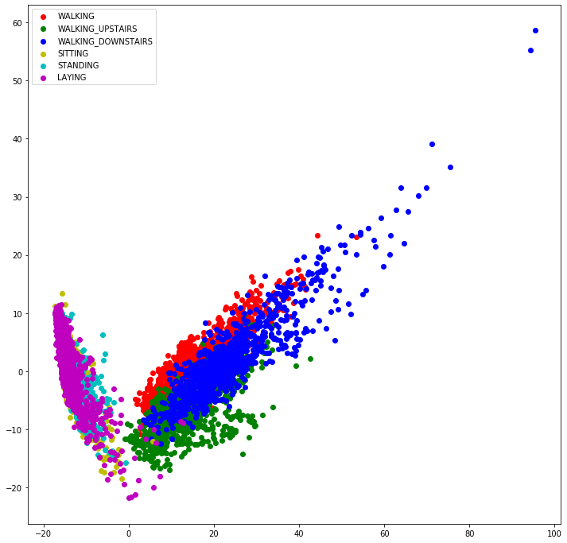

```python
from sklearn.decomposition import PCA

pca = PCA(n_components=5)
print(pca)


pca.fit(feature_nor)    # ajuster la PCA sur les données features_nor
PCA(copy=True, iterated_power='auto', n_components=5, random_state=None,
  svd_solver='full', tol=0.0, whiten=False)  # transformer (prediction) les données features_nor pour le modele PCA
DataExtract = pca.transform(feature_nor)


ACP0 = DataExtract[:,0] ### TODO ### extraction premiere composante
ACP1 = DataExtract[:,1] ### extraction deuxieme composante

plt.figure(figsize=(12, 12))
# iterer sur les activités et utiliser un zip pour
# faciliter la representation graphique des objets
# sur lesquels on itere
for c, i, act in zip("rgbycm", range(0,6),activity_names):
    plt.scatter(ACP0[activity==i],ACP1[activity==i], c=c, label=act)

plt.legend()
```

# Problème de classification à deux classes

Dans toute la première partie du TP, on considère un problème de classification à deux classes.

> Extraire les donnnés pour les activités 3 et 4 uniquement. On appelera `features34` et `activity34` les données correspondantes.

```python
n,p = shape(feature_nor)
index_act34 = [i for i in range(n) if activity[i]==3 or activity[i]==4 ]
activity34 = [activity[i] for i in index_act34 ]

features34 = [feature_nor[i] for i in index_act34]
print(shape(features34))
```

```
(2660, 561)
```

# Présélection de features pour réduire la dimension (screening)

Pour diminuer les temps de calul on peut pré-sélectionner les 100 features les plus discriminants via un critère univarié.

> Utiliser le critère [SelectKBest](http://scikit-learn.org/stable/modules/generated/sklearn.feature_selection.SelectKBest.html) basé sur la F-value (variance inter / variance intra).

Attention, cette méthode ne garantit en rien que l'on a choisi le "meilleur" groupe de 100 variables pour le problème de classification.

```python
from sklearn.feature_selection import SelectKBest, f_classif
Selec = SelectKBest(f_classif,k=100)
features34 = Selec.fit_transform(features34,activity34)
shape(features34)
```

```
(2660, 100)
```

# Ajustement pour des méthodes classiques de classification

> Pour chacune des méthodes de classificiation listées ci-dessous, construire un predicteur de l'activité en utilisant comme données d'apprentissage la base (features34,activity34) :
> - Classifieur naif bayesien avec la fonction `GaussianNB()`
> - Classifieur des k plus proches voisins avec `neighbors.KNeighborsClassifier()`
> - Classifieur par régression logistique, avec pénalisation ridge puis avec une pénalisation lasso, en utilisant la fonction `linear_model.LogisticRegression()`

Une présentation de chacune des ces fonctions est accessible depuis cette [page](http://scikit-learn.org/stable/user_guide.html). </p>

```python
from sklearn.naive_bayes import GaussianNB
gnb = GaussianNB()
gnb.fit(features34,activity34)


from sklearn import neighbors
nn = neighbors.KNeighborsClassifier()
nn.fit(features34,activity34)


from sklearn import linear_model
logit =  linear_model.LogisticRegression(random_state=0, solver='lbfgs', multi_class='multinomial')
logit.fit(features34,activity34)
```

```
LogisticRegression(C=1.0, class_weight=None, dual=False, fit_intercept=True,
                   intercept_scaling=1, l1_ratio=None, max_iter=100,
                   multi_class='multinomial', n_jobs=None, penalty='l2',
                   random_state=0, solver='lbfgs', tol=0.0001, verbose=0,
                   warm_start=False)
```

# Evaluation de l'erreur avec un découpage train / test

> Estimer les performances de classification sur l'échantillon d'apprentissage conduit à sous-estimer systématiquement l'erreur de généralisation du prédicteur construit. Calculer l'erreur estimée sur les données d'apprentissage. Utiliser pour cela la fonction `.score()` pour chacune des méthodes.

```python
g =gnb.score(features34,activity34)
print ( 1-g )
n = nn.score(features34,activity34)
print ( 1-n )
l = logit.score(features34,activity34)
print ( 1-l )
```

```
0.19436090225563907
0.0390977443609023
0.0379699248120301
```

On peut contourner ce problème de surapprentissage systématique en utilisant un ensemble de validation. Pour cela on considère deux échantillons :

- l'ensemble d'apprentissage : utilisé pour construire des prédicteurs ;
- l'ensemble de test : utilisé pour évaluer les performances des prédicteurs.

> Utiliser la fonction `train_test_split` du module [`model_selection`](http://scikit-learn.org/stable/modules/classes.html#module-sklearn.model_selection) pour construire un échantillon d'apprentissage de taille 60% (et donc 40% réservées aux données de test)

```python
from sklearn import model_selection

features_train, features_test, activity_train, activity_test = model_selection.train_test_split ( features34 , activity34 , test_size=0.4, random_state=42)
print(len(activity_train)/ float(len(activity34)))
print(len(activity_test)/ float(len(activity34)))
print(shape(features_test))
```

```
0.6
0.4
(1064, 100)
```

> Evaluer le risque d'un classifieur par plus proches voisins sur ce découpage des données :

```python
nn_train = neighbors.KNeighborsClassifier()
nn_train.fit(features_train,activity_train)

nn_train_score = nn_train.score(features_test,activity_test)
print( 1-nn_train_score )
```

```
0.09774436090225569
```

> Reproduire la procédure 100 fois et dresser le boxplot de l'estimation de l'erreur sur ces 100 runs.

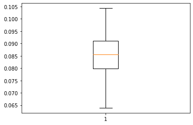

```python
score_train_test = [] # pour stockage des scores
for simu in range(100) :
    features_train, features_test, activity_train, activity_test = model_selection.train_test_split ( features34 , activity34 , test_size=0.4)
    nn_train_test = neighbors.KNeighborsClassifier(n_neighbors = 3)
    nn_train_test.fit(features_train, activity_train)
    nn_train_test_score = nn_train_test.score(features_test,activity_test)
    score_train_test.append([1-nn_train_test_score])

#on récupère les données nécessaires à la boîte à moustache
array_score_train_test = np.array(score_train_test)
B = plt.boxplot(array_score_train_test)
```

> Tracer la courbe d'erreur du classifieur par plus proches voisins en fonction du nombre de voisins utilisés (de 1 à 15), en utilisant cette méthode de découpage train / test répétée 20 fois.

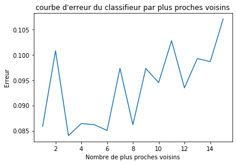

```python
list_score_train_test =[]


#De i=1 à 15 voisins
for i in range(1,16) :
    # pour stockage des scores
    score_train_test = []
    for simu in range(20) :
        features_train, features_test, activity_train, activity_test = model_selection.train_test_split ( features34 , activity34 , test_size=0.4)
        nn_train_test = neighbors.KNeighborsClassifier(n_neighbors = i)
        nn_train_test.fit(features_train, activity_train)
        nn_train_test_score = nn_train_test.score(features_test,activity_test)
        score_train_test.append([1-nn_train_test_score])
    list_score_train_test += [np.array(score_train_test).mean()]

plt.plot([i for i in range(1,16)],list_score_train_test )
plt.title("courbe d'erreur du classifieur par plus proches voisins")
plt.xlabel("Nombre de plus proches voisins")
plt.ylabel("Erreur")
plt.show()
```

En réalité, si l'on désire une estimation du modèle sélectionné ainsi, il faut découper l'échantillon disponible non pas en deux mais en trois parties :

- l'ensemble d'apprentissage : utilisé pour construire des modèles ;
- l'ensemble de validation : utilisé pour choisir un modèle ;
- l'ensemble de test : utilisé pour évaluer les performances du modèle finalement choisi.

Ceci est notamment important lorsque l'on souhaite comparer deux méthodes qui ont toutes les deux fait intervenir un réglage de paramètres (ici le nombre de voisins).

> Illustrer l'interet sur split en 3 parties pour l'exemple du knn (finir le tp avant de répondre à cette question)

# Estimation du risque par validation croisée

On présente ci-dessous la méthode du de validation croisée de type **k-fold**.

L'idée principale est de faire jouer à chaque observation à la fois le rôle de donnée d'apprentissage et celui de donnée de validation.

Le principe consiste à partitionner aléatoirement les données $D=(\mathbf{x}_i,y_i)_{1\leq i\leq N} $ en $K$ blocs disjoints de tailles comparables : $D^1,\ldots,D^K$. On prend généralement $K=5$ ou $10$. La méthode du **leave-one-out (Loo)** correpond au choix $K=N-1$.

On estime alors la qualité d'un type de predicteur $\hat f$ de la façon suivante :

- pour tout $k \in \{1,\dots, K\}$, on construit un predicteur $\hat f^k$ (du même type que $\hat f$) sur l'ensemble d'apprentissage $D^{-k} := D\setminus D^k$ ;
- on estime le risque du prédicteur $\hat f$ par
  $$ \frac{1}{N}\sum_{k=1}^K\sum_{\mathbf{x}_i\in D^k} \ell(\hat f^k(\mathbf{x}_i),y_i), $$ où $\ell$ est la perte utilisée.

On construit donc autant de prédicteurs qu'il y a de blocs dans l'ensemble d'apprentissage. Chaque prédicteur est évalué sur les éléments du bloc qui n'a pas été utilisé pour l'apprentissage (et qui joue donc le rôle d' ensemble de validation).

Lorsque l'on souhaite régler un paramètre en utlisant la validation croisée, par exemple le nombre de voisins $k$ pour knn, on procède comme suit :

- on évalue les performances des prédicteurs par validation croisée comme expliqué ci-dessus ;
- on détermine la valeur optimale du paramètre ;
- on construit finalement un predicteur pour le paramètre sélectionné, en utilisant comme base d'apprentissage toutes les données.

**Comparaison entre LOO et methodes k folds, quelques repères :**

- LOO a un coût computationnel plus élevé que les méthodes k-fold pour k petit (pour k = 5 ou 10 par exemple)
- L'estimation de l'erreur fournie par LOO a généralement une variance plus élevée que celles obtenues par un k-fold pour k petit.
- En revanche, si l'erreur de classification décroit très rapidement avec $n$, les méthodes k-fold avec k petit peuvent surestimer significativement l'erreur de généralisation.
- En général, il est souvent recommandé d'utiliser les méthodes k-fold avec k = 5 ou 10.

### Estimation de l'erreur par 10-fold :

```python
nn_val_croisee = neighbors.KNeighborsClassifier(n_neighbors = 10)
scores = model_selection.cross_val_score(nn_val_croisee, features34, activity34, cv=10)
print(scores)
print(mean(scores))
```

```
[0.90636704 0.83520599 0.85018727 0.81273408 0.88345865 0.80451128
 0.91320755 0.95849057 0.84150943 0.88679245]
0.8692464306834502
```

### Estimation de l'erreur par Loo

> Utiliser la fonction `LeaveOneOut` de `model_selection` pour évaluer l'erreur du classifieur de plus proches voisin (pour 10 voisins).

```python
from sklearn.model_selection import LeaveOneOut

loo = LeaveOneOut()

for train_index, test_index in loo.split(features34, activity34):
        X_train, X_test = feature_nor[train_index], feature_nor[test_index]
        y_train, y_test = activity[train_index], activity[test_index]
        nn_val_croisee = neighbors.KNeighborsClassifier(n_neighbors = 10)
        nn_val_croisee.fit(features_train, activity_train)
        nn_score = nn_val_croisee.score(feature_test,activity_test)
        nn_scores += [nn_score]
print(np.score(nn_scores).mean())

print(square_error_sum)
```

[output not shown]